# Equations

## Constants

Tennis ball is object 1. Foam ball is object 2. Collision times are approximated as it is hard to measure.
$$\begin{align}
m_{1}&=0.057 \ \phantom{}kg\\
m_{2}&= 0.020\ kg \\
t_{collision\ 1}&\approx 0.304 \ s \\
\Delta t_{collision\ 1}&\approx 0.025 \ s\\
t_{collision\ 2}&\approx 0.433 \ s \\
\Delta t_{collision\ 2}&\approx 0.016 \ s\\
\end{align}$$

## Tennis Ball

$$x_{1} = \begin{cases}
(-0.015\ m) + (\phantom{-}
1.581\ \frac{m}{s})\, t & 0.000\ s \leqslant t \leqslant 0.295\ s\\
(-0.773\ m) + (-1.090\ \frac{m}{s})\, t & 0.326\ s \leqslant t
\leqslant 0.431\ s\\
(\phantom{-}
0.427\ m) + (-0.329\ \frac{m}{s})\, t & 0.450\ s \leqslant t
\leqslant 1.196\ s
\end{cases}$$
$$y_{1} = \begin{cases}
(\phantom{-}0.264\ m) + (-0.264\ \frac{m}{s}) t & 0.000\ s \leqslant
t \leqslant 0.286\ s\\
(\phantom{-}0.246\ m) + (-0.196\ \frac{m}{s}) t & 0.297\ s \leqslant
t \leqslant 0.419\ s\\
(\phantom{-}0.187\ m) + (-0.058\ \frac{m}{s}) t & 0.476\ s \leqslant
t \leqslant 1.197\ s
\end{cases}$$
$$v_{1x} = \begin{cases}
(\phantom{-}1.866\ \frac{m}{s}) + (-1.841\ \frac{m}{s^2}) t & 0.000\
s \leqslant t \leqslant 0.295\ s\\
(-2.284\ \frac{m}{s}) + (\phantom{-}3.233\ \frac{m}{s^2}) t & 0.326\
s \leqslant t \leqslant 0.431\ s\\
(-0.599\ \frac{m}{s}) + (-0.308\ \frac{m}{s^2}) t & 0.450\ s
\leqslant t \leqslant 1.196\ s
\end{cases}$$
$$v_{1y} = \begin{cases}
(-0.275\ \frac{m}{s}) + (\phantom{-}0.030\ \frac{m}{s^2}) t & 0.000\
s \leqslant t \leqslant 0.286\ s\\
(\phantom{-}0.505\ \frac{m}{s}) + (-1.958\ \frac{m}{s^2}) t & 0.297\
s \leqslant t \leqslant 0.419\ s\\
(-0.085\ \frac{m}{s}) + (\phantom{-}0.036\ \frac{m}{s^2}) t & 0.476\
s \leqslant t \leqslant 1.197\ s
\end{cases}$$
$$|v_{1}| = \sqrt{
{v_{1x}}^2+{v_{1y}}^2 }=\begin{cases}
(\phantom{-}1.848\ \frac{m}{s}) + (-1.505\ \frac{m}{s^2}) t & 0.000\
s \leqslant t \leqslant 0.286\ s\\
(\phantom{-}1.139\ \frac{m}{s}) + (-0.062\ \frac{m}{s^2}) t & 0.316\
s \leqslant t \leqslant 0.411\ s\\
(\phantom{-}0.528\ \frac{m}{s}) + (-0.225\ \frac{m}{s^2}) t & 0.509\
s \leqslant t \leqslant 1.190\ s
\end{cases}$$

## Foam Ball

$$x_{2} = \begin{cases}
(\phantom{-}0.253\ m) + (\phantom{-}0.000\ \frac{m}{s}) t & 0.000\ s
\leqslant t \leqslant 0.430\ s\\
(\phantom{-}0.439\ m) + (-0.442\ \frac{m}{s}) t & 0.441\ s \leqslant
t \leqslant 1.090\ s
\end{cases}$$
$$y_{2} = \begin{cases}
(\phantom{-}0.112\ m) + (\phantom{-}0.000\ \frac{m}{s}) t & 0.000\ s
\leqslant t \leqslant 0.430\ s\\
(\phantom{-}0.260\ m) + (-0.355\ \frac{m}{s}) t & 0.441\ s \leqslant
t \leqslant 1.090\ s
\end{cases}$$
$$v_{2x} = \begin{cases}
(\phantom{-}0.000\ \frac{m}{s}) + (\phantom{-}0.000\ \frac{m}{s^2}) t
& 0.000\ s \leqslant t \leqslant 0.430\ s\\
(-0.575\ \frac{m}{s}) + (\phantom{-}0.172\ \frac{m}{s^2}) t & 0.441\
s \leqslant t \leqslant 1.090\ s
\end{cases}$$
$$v_{2y} = \begin{cases}
(\phantom{-}0.000\ \frac{m}{s}) + (\phantom{-}0.000\ \frac{m}{s^2}) t
& 0.000\ s \leqslant t \leqslant 0.430\ s\\
(-0.459\ \frac{m}{s}) + (\phantom{-}0.129\ \frac{m}{s^2}) t & 0.441\
s \leqslant t \leqslant 1.090\ s
\end{cases}$$
$$|v_{2}|
= \sqrt{ {v_{2x}}^2+{v_{2y}}^2}=\begin{cases}
(\phantom{-}0.000\ \frac{m}{s}) + (\phantom{-}0.000\ \frac{m}{s^2}) t
& 0.000\ s \leqslant t \leqslant 0.412\ s\\
(\phantom{-}0.735\ \frac{m}{s}) + (-0.211\ \frac{m}{s^2}) t & 0.446\
s \leqslant t \leqslant 1.090\ s
\end{cases}$$

## Center of Mass (CoM)

$$x_{cm} = \begin{cases}
(\phantom{-}0.054\ m) + (\phantom{-}1.171\ \frac{m}{s}) t & 0.000\ s
\leqslant t \leqslant 0.294\ s\\
(\phantom{-}0.642\ m) + (-0.818\ \frac{m}{s}) t & 0.317\ s \leqslant
t \leqslant 0.421\ s\\
(\phantom{-}0.428\ m) + (-0.361\ \frac{m}{s}) t & 0.464\ s \leqslant
t \leqslant 1.090\ s
\end{cases}$$
$$y_{cm} = \begin{cases}
(\phantom{-}0.224\ m) + (-0.196\ \frac{m}{s}) t & 0.000\ s \leqslant
t \leqslant 0.294\ s\\
(\phantom{-}0.219\ m) + (-0.166\ \frac{m}{s}) t & 0.317\ s \leqslant
t \leqslant 0.421\ s\\
(\phantom{-}0.208\ m) + (-0.138\ \frac{m}{s}) t & 0.464\ s \leqslant
t \leqslant 1.090\ s
\end{cases}$$
$$v_{cm,x} =
\begin{cases}
(\phantom{-}1.354\ \frac{m}{s}) + (-1.132\ \frac{m}{s^2}) t & 0.000\
s \leqslant t \leqslant 0.284\ s\\
(-0.768\ \frac{m}{s}) + (-0.148\ \frac{m}{s^2}) t & 0.320\ s
\leqslant t \leqslant 0.392\ s\\
(-0.586\ \frac{m}{s}) + (\phantom{-}0.276\ \frac{m}{s^2}) t & 0.467\
s \leqslant t \leqslant 1.090\ s
\end{cases}$$
$$v_{cm,y} =
\begin{cases}
(-0.205\ \frac{m}{s}) + (\phantom{-}0.030\ \frac{m}{s^2}) t & 0.000\
s \leqslant t \leqslant 0.284\ s\\
(\phantom{-}0.410\ \frac{m}{s}) + (-1.527\ \frac{m}{s^2}) t & 0.320\
s \leqslant t \leqslant 0.392\ s\\
(-0.169\ \frac{m}{s}) + (\phantom{-}0.048\ \frac{m}{s^2}) t & 0.467\
s \leqslant t \leqslant 1.090\ s
\end{cases}$$
$$v_{cm} =
\sqrt{ {v_{cm,x}^2}+{v_{cm,y}^2}}=\begin{cases}
(\phantom{-}1.370\ \frac{m}{s}) + (-1.121\ \frac{m}{s^2}) t & 0.000\
s \leqslant t \leqslant 0.284\ s\\
(\phantom{-}0.937\ \frac{m}{s}) + (-0.262\ \frac{m}{s^2}) t & 0.320\
s \leqslant t \leqslant 0.392\ s\\
(\phantom{-}0.601\ \frac{m}{s}) + (-0.265\ \frac{m}{s^2}) t & 0.467\
s \leqslant t \leqslant 1.090\ s
\end{cases}$$

# Analysis

## Introduction

This is a tricky situation to analyze and discuss due to the immense amount of data, graphs (15 to be exact), and equations (also 15, but balloons to 40 if you include each branch of the piecewise). Instead, I will only focus on the relevant parts to what we covered in this past unit, linear momentum.

These equations were generated from 15 graphs which were created in Logger Pro's video analysis tool. Because this was human generated, there are errors. Most notably, there are errors in the velocity graphs in comparison to the position graphs. I believe Logger Pro calculates the instantaneous derivative of each point does something to create the velocity graph which is completely separate from using the linear fit tool (which works on a collection of points).

Friction is tricky in this scenario. As this was not taken in a lab, instead taking on the floor of my room, there are possible external factors that could affect the result of this experiment. The shape of the position vs time graphs seem linear, and not quadratic, meaning I do not believe friction plays a significant role on the velocity of the objects. This also makes me conclude that errors in the velocity graphs are likely due to human error and not the surface.

Additionally, parallax errors could possibly have caused errors in the data. I tried to mitigate this by stopping the video analysis when the foam ball rolled too farm down.

## Scenario

A tennis ball is launched at a wall. It bounces off at an angle. Then, it strikes a foam ball (starting at rest) at an angle.

This was filmed at 240 frames per second (fps) using a GoPro and analyzed at 120 fps. The GoPro was attached to the side of my desk via a magnet.

## Collision 1

Collision 1 is defined as the collision between the tennis ball and the wall occurring at $t_{collision\ 1}= \sim 0.304 \ s$. I hypothesize that this is an elastic collision because the wall stays at rest for the entirety.

### X-component

We can check this using the law of conservation of momentum and the conservation of kinetic energy. Momentum is the product of velocity and mass, representing an objects tendency to change momentum ($\vec{p}=m\vec{v}$). The law of conservation of momentum states that the initial momentum of a system (in the state of a collision) is equivalent to the final momentum of a system ($\vec{p_{i}}=\vec{p_{f}}$) if no external forces are involved. To analyze, this problem needs to be broken up into two components, $x$ and $y$, as momentum is a vector.

Law of conservation of momentum:
$$\rlap{%
\cancel{%
\begin{aligned}
p_{ix}&=p_{fx} \\
m_{1}v_{ix} + m_\text{wall} \cancelto{0}{v_\text{wall,x}} &=
m_{1}v_{fx} + m_\text{wall} \cancelto{0}{v_\text{wall,x}} \\
m_{1}v_{ix} &= m_{1}v_{fx} \\
v_{ix} &= v_{fx}
\end{aligned}%
}%
}%
\bcancel{%
\begin{aligned}
p_{ix}&=p_{fx} \\
m_{1}v_{ix} + m_\text{wall} \cancelto{0}{v_\text{wall,x}} &=
m_{1}v_{fx} + m_\text{wall} \cancelto{0}{v_\text{wall,x}} \\
m_{1}v_{ix} &= m_{1}v_{fx} \\
v_{ix} &= v_{fx}
\end{aligned}%
}%$$
$v_{ix}$ and $v_{fx}$ are defined as the initial and final velocity, respectively, of the collision. We can extrapolate these numbers from the graph of $v_{1x}$ using the first two piecewises.
$$\rlap{%
\cancel{%
\begin{aligned}
v_{ix} &= v_{1x}(0.295 \ s) = 1.322\ \frac{m}{s} \\
v_{fx} &= v_{1x}(0.326 \ s) = -1.23\ \frac{m}{s}
\end{aligned}%
}%
}%
\bcancel{%
\begin{aligned}
v_{ix} &= v_{1x}(0.295 \ s) = 1.322\ \frac{m}{s} \\
v_{fx} &= v_{1x}(0.326 \ s) = -1.23\ \frac{m}{s}
\end{aligned}%
}%$$

I thought we could apply the laws of conservation of momentum to the wall –apparently, you can't ([O'Naraigh et al., 2022, p. 11](https://maths.ucd.ie/~onaraigh/acm10080/thesis.pdf#page=121)). I thought that because $v_{wall,i} = v_{wall,f} = 0$, I could still use the conservation of momentum equations, which is not true. If you think about this situation (or read the paper linked), you should come to realize that the final velocity should the negative of the initial velocity ($v_{ix} = -v_{fx}$). In this situation, this can be tested out. Using data extrapolated from the velocity graphs.
$$\begin{aligned}
v_{ix} &= v_{1x}(0.295 \ s) = \phantom{-}1.322\ \frac{m}{s} \\
v_{fx} &= v_{1x}(0.326 \ s) = -1.230\ \frac{m}{s}
\end{aligned}$$
Using the percent change formula to compare the magnitudes differences of velocities,
$$\frac{|v_{fx}|-|v_{ix}|}{|v_{ix}|}=\frac{1.322-1.23}{1.322}=-0.0695915279879=-6.969\%$$
This is important because it shows that there are external factors that affect the system ($F_{sys,net}\ne 0$). However, this could be equally due to experimental errors or actual unknown external forces.

Conservation of kinetic energy is true if the collision is elastic. However, as the magnitude difference is $6.969 \%$, kinetic energy ($K=\frac{1}{2}mv^2$) is not expected to be conserved.
$$\begin{align}
K_{i}&=K_{f} \\
\frac{1}{2}m_{1}{v_{ix}}^2&=\frac{1}{2}m_{1}{v_{fx}}^2 \\
{v_{ix}}^2&={v_{fx}}^2
\end{align}$$
This expresses the same thing as $v_{ix} = -v_{fx}$, confirming the suspicion that kinetic energy is not conserved.

$$\begin{align}
K_{i}&=K_{f} \\
\frac{1}{2}m_{1}{v_{ix}}^2&=\frac{1}{2}m_{1}{v_{fx}}^2 \\
0.049 \ J &= 0.043 \ J \\ \\
\end{align}$$
Calculate the change in kinetic energy:
$$\begin{align}
\frac{0.043 - 0.049}{0.049} = -0.122448979592 = -12.24 \%
\end{align}$$

This shows that kinetic energy is not conserved because there is a $-12.24 \%$ change from the initial to the final. This also means that the collision is inelastic, not elastic or completely inelastic.

Impulse, $\Delta \vec{p}$, is defined as the change in momentum. $\Delta \vec{p}=m\Delta \vec{v}=\vec{F}\Delta t$. As it is a vector, it needs to be broken up into components. The x-component is below, while the y-component is in the next section.
$$\begin{align}
\Delta p_{x}&=m\Delta v_{x} \\
\Delta p_{x}&=m_{1}(v_{fx}-v_{ix}) \\
&=-0.145 \ kg \frac{m}{s} \\
\end{align}$$
Force:
$$\begin{align}
\Delta p&=F\Delta t \\
\Delta p_{x}&=F_{x}\Delta t_{collison\ 1} \\
F_{x}&=\frac{\Delta p_{x}}{\Delta t_{collison\ 1}} \\
&=-5.8 \ N
\end{align}$$
This means that the x component of the average force from the ball onto the wall was $-5.8 \ N$. The negative sign indicates that the force was opposite the balls motion. This is equivalent to the gravitational force acting on a $0.591 \ kg$ mass ($\frac{5.8 \ N}{9.8 \ \frac{m}{s^2}}=0.591\ kg$).

### Y-component

As we have analyzed the x-component of the velocity, the y-component can also be analyzed. This section can be kept brief as I have already learned the hard way that conservation of momentum does not apply in this scenario.

In the x-component, we used $v_{ix}=-v_{fx}$. This doesn't hold for the y-component, as a reflection never occurs along the y-axis. Instead, it is expected that $v_{iy}=v_{fy}$ holds true.
$$\begin{align}
v_{iy} &= v_{1y}(0.286 \ s) = -0.266\ \frac{m}{s} \\
v_{fy} &= v_{1y}(0.297 \ s) = -0.076\ \frac{m}{s}
\end{align}$$
Clearly, the final y velocity seems to be incorrect (as the tennis ball is not near at rest following the collision). Instead, the derivative can be taken from the Y vs T graph.
$$v_{fy}={y_{1}}'(0.297)=-0.196 \frac{m}{s}$$
Comparing the change in y-velocity:
$$\frac{v_{fy}-v_{ix}}{v_{fy}}=\frac{-0.196-(-0.266)}{-0.266}=-0.263157894737=-26.31\%$$
Using this correct data, it seems that the y-component of the velocity experiences a negative acceleration after colliding with the wall.

Conservation of kinetic energy, showing that the kinetic energy is not conserved because it decreases by $50 \%$.
$$\begin{align}
K_{i}&=K_{f} \\
\frac{1}{2}m_{1}{v_{iy}}^2&=\frac{1}{2}m_{1}{v_{fy}}^2 \\
0.002 \ J &= 0.001 \ J
\end{align}$$
$$\begin{align}
\frac{0.001 - 0.002}{0.002} &= -0.5= -50 \%
\end{align}$$
The impulse for the y-component can also be calculated:

$$\begin{align}
\Delta p_{y}&=m\Delta v_{y} \\
\Delta p_{y}&=m_{1}(v_{fy}-v_{iy}) \\
\Delta p_{y}&=0.003 \ kg\frac{m}{s} \\
\end{align}$$
The impulse is significant, especially in comparison to $\Delta p_{x}$. $\Delta p_{x}$ has an impulse of $-0.145 \ kg \frac{m}{s}$ which is much larger than $\Delta p_{y} = 0.003 kg \frac{m}{s}$. This means that the x-component of the velocity experienced more force than the y-component in the time interval of the collision, due to $\Delta p=m\Delta v=F\Delta t$. This is consistent with the graphs, where the Y vs T graph slope doesn't change as much compared to the X vs T graph.

$$\begin{align} \\
\Delta p&=F\Delta t \\
\Delta p_{y}&=F_{y}\Delta t_{collison\ 1} \\
F_{y}&=\frac{\Delta p_{y}}{\Delta t_{collison\ 1}} \\
F_{y}&=0.12 \ N
\end{align}$$
The y-component of the force is small —equivalent to the gravitational force on an object of $0.012 \ kg$. This further shows that collision primarily affected the motion in the x-direction.

### Coefficient of Restitution/Elasticity

The coefficient of restitution, $e$, represents the elasticity in a clamped range of $[0,1]$ where $1$ represents an elastic collision and $0$ represents an inelastic collision. Similarity, if the kinetic energy of the system does not change ($\Delta K_{sys}=0$), then the collision is elastic (and $e = 1$).

In this scenario, the coefficient of restitution is only defined for the x-component of the collision as y-component does not affect the "bounciness" of this collision.

The general formula for coefficient of restitution: $e=\frac{|v_{1f}-v_{2f}|}{|v_{1i}-v_{2f}|}$.
$$\begin{align}
e&=\frac{|v_{fx}-\cancelto{0}{v_{wall}}|}{|v_{ix}-\cancelto{0}{v_{wall}}|}
\\
e&=\frac{|v_{fx}|}{|v_{ix}|} \\
e&=0.93
\end{align}$$
This means that the collision was inelastic, since $e < 1$. This also means that some kinetic energy is lost during the collision even though the ball retains most of its speed in the x-direction.

## Collision 2

This is the collision between the tennis ball and the foam ball. Unlike the previous collision (1, tennis ball with wall), the laws of conservation of momentum apply since the mass of the two objects are known. This occurs at $t_{collision\ 2}= \sim 0.433 \ s$.

### Key Variables

**Tennis ball:**
$$\begin{align}
v_{1ix}=v_{1x}(0.431 \ s)=-0.890 \ \frac{m}{s} \\
v_{1fx}=v_{1x}(0.450 \ s)=-0.737 \ \frac{m}{s} \\
v_{1iy}=v_{1y}(0.419 \ s)=-0.315 \ \frac{m}{s} \\
v_{1fy}=v_{1y}(0.476 \ s)=-0.067 \ \frac{m}{s}
\end{align}$$
**Foam ball:** Time intervals are consistent between the x and y velocities, meaning that the data is cleaner than the ones from the previous collision.
$$\begin{align}
v_{2ix}=v_{2x}(0.430 \ s)=\phantom{-}0.000 \frac{m}{s} \\
v_{2fx}=v_{2x}(0.441 \ s)=-0.499 \frac{m}{s} \\
v_{2iy}=v_{2y}(0.430 \ s)=\phantom{-}0.000 \frac{m}{s} \\
v_{2fy}=v_{2y}(0.441 \ s)=-0.402 \frac{m}{s}
\end{align}$$

### Forces

The force of the collision on each object can also be calculated using $\Delta p=F\Delta t$.

The tennis ball experienced an average force equivalent to the force of gravity on a mass of $0.102 \ kg$.

$$\begin{align} F_{1x}&=\frac{\Delta p_{1x}}{\Delta t_{collision \
2}} \\ &=0.500 \ N \\
F_{1y}&=\frac{\Delta p_{1y}}{\Delta t_{collision \ 2}} \\
&=0.875 \ N \\ |F_{1}|&=\sqrt{ {F_{1x}}^2+{F_{1y}}^2 } \\
&=1.007 \ N \end{align}$$

The foam ball experienced an average force equivelent to the force of gravity on a mass of $0.076 \ kg$:

### Conservation of Momentum

Unlike the first collision, momentum should theoretically be conserved as we know the two masses. The law of conservation states that the initial momentum of a system is the same as the final momentum of a system. In this scenario, I hypothesize that momentum is very closed to being conserved. I do not think it is fully conserved due to external factors such as experimental errors, human error, or even friction.

Law of conservation of momentum: $\vec{p}_{sys,i}=\vec{p}_{sys,f}$ where $\vec{p}_{sys} = \sum \limits_{m} p_{n}$ where $p_{n}=m_{n}v_{n}$. As this is a vector, it needs to be broken up into components. For simplicity, I will not recalculate these values, having calculated them earlier in this section. For this collision, the system is only the tennis ball and foam ball.
$$\begin{align}
p_{sys,x,i}&=\sum \limits_{n}m_{n}v_{ni} \\
&=p_{1ix}+p_{2ix} \\
&=-0.050 \ kg \frac{m}{s} \\
p_{sys,x,f}&=\sum \limits_{n}m_{n}v_{ni} \\
&=p_{1fx}+p_{2fx} \\
&=-0.051 \ kg \frac{m}{s}
\end{align}$$
This essentially proves momentum is conserved along the x-axis as the difference between the values is only $2\%$ ($|\frac{p_{sys,x,f}-p_{sys,x,i}}{p_{sys,x,i}}|$). This is likely not due to external forces, instead likely being caused by experimental error. Additionally, the small difference proves that this collision has better data (and thus less experimental error), than the first collision.

### Coefficient of Restitution/Elasticity

Like collision 1, the elasticity of the collision can be calculated. First, the magnitudes of the velocities need to be calculated. Then $\Delta K_{sys}=0$ can be checked.

A collision is elastic if $K_{i}=K_{f}$ ($K_{f}-K_{i}=0 \to \Delta K=0$). Kinetic energy, $K=\frac{1}{2}mv^2$, is a scalar, so it does not need to be broken up into components. This means that magnitude of the velocity can be used instead of the components.

$$\begin{align}
|v_{1i}|&= \sqrt{{v_{1ix}}^2 +{v_{1iy}}^2} &= 0.944
\frac{m}{s}\\
|v_{1f}|&= \sqrt{{v_{1fx}}^2 +{v_{1fy}}^2} &= 0.740
\frac{m}{s}\\
|v_{2i}|&= \sqrt{{v_{2ix}}^2 +{v_{2iy}}^2} &= 0.000
\frac{m}{s}\\
|v_{2f}|&= \sqrt{{v_{2fx}}^2 +{v_{2fy}}^2} &= 0.640
\frac{m}{s}\\
\end{align}$$
$$\begin{align}
K_{sys,i}&= \frac{1}{2}m_{1}{|v_{1i}|}^2
+\frac{1}{2}m_{2}{|v_{2i}|}^2 \\
&=0.025 \ J\\
K_{sys,f}&= \frac{1}{2}m_{1}{|v_{1f}|}^2
+\frac{1}{2}m_{2}{|v_{2f}|}^2 \\
&=0.019 \ J \\
\end{align}$$
This means that the collision is not elastic, instead being inelastic. The kinetic energy changed by $24\%$ ($|\frac{K_{sys,f}-K_{sys,i}}{K_{sys,i}}|$) during the collision. However, the coefficient of restitution is hard to calculate in this case, because the velocities need to be projected along the line of impact. Qualitatively, I expect the coefficient of restitution to be less than 1 as some kinetic energy along the line of impact was lost.

## Center of Mass (CoM) for Tennis Ball and Foam Ball

### Position

If momentum of a system is conserved, the graph of $v_{cm}$ is constant (derived from $p_{i}=p_{f}$). On a $x_{cm}$ graph, the line would be linear. Phases of 2 and 3 of the x and y center of masses show this as they are both linear. However, they have slightly different slopes which shows that momentum is not conserved.

### Velocity

The theoretical formulas:
$$\begin{align}
v_{cm,x}&=\frac{\sum \limits_{i} m_{i}v_{ix}}{\sum \limits_{i}
m_{i}} \\ \\
v_{cm,y}&=\frac{\sum \limits_{i} m_{i}v_{iy}}{\sum \limits_{i}
m_{i}} \\
\end{align}$$
These equations essentially represent the momentum of the system over mass of the system. The numerator, $\sum \limits_{i}m_{i}v_{i}$, is the same as $\sum p$ where $p=mv$. This means that if momentum is conserved, the velocity would be constant. In this case, the equations are not constant —they are linear—, which shows that momentum is not conserved. This is further proven by the use of a piecewise function for second and third intervals, which represent the time between collision 1 and 2 and the time after collision 2.

# Conclusion

In this experiment, there is significant experimental error, as previously proved through the inconsistent data.

The most obvious source of error: humans. Human error played a large part, as the data was analyzed in Logger Pro not by an automatic system, but by a human. I had to manually label the points on the video. I had to manually figure out the center of the object, a hard task. Originally, I recorded the video at 240 frames per second (fps), because I wanted more data to remove outliers. However, labeling points at 240 fps means that the data points are very close together, which I had a hard time trying to label. To mitigate this error, I analyzed the points at 120 fps. This helped to reduce the inconsistency in location of the points at the cost of less data.

Another source of error is the parallax effect. Filming the scene required considerable effort. It was late at night and my room was dark. I used a lamp to provide more light. I wanted to film at a high fps so I used my GoPro, mounted to the leg of my desk as I had no better place to put it. This likely introduced some parallax errors especially towards the end of the video as the foam ball starts to roll out of frame. I believe I partially mitigated this by ending the video analysis when the foam ball's shape started to warp.

Another source of error likely stems from the usage of significant figures. I truncated everything at three decimals for consistency, partially because the precision of measurements was uncertain. This could possibly introduce errors over time as data is truncated for future calculations. I attempted to mitigate this by checking my work over the original values and then truncating.

A significant source of error is the frame rate. The video was recorded at 240 fps and analyzed at 120 fps. This means that each frame is only $\frac{1 \ s}{120 \ frames}=8.33 \ ms$. This introduces uncertainty for collision time intervals. A collision lasting $\approx 0.025 \ s$ spans only 3 frames, and a collision lasting $\approx 0.016 \ s$ spans only 2 frames. This introduces uncertainty: an error of 1 frame in timing introduces an error of $\pm 8.33 \ ms$, which is significant relative to the short collision duration.

The results of this scenario have numerous real world applications. Momentum and impulse are critical in vehicle safety testing. Impulse explains how increasing the collision time reduces the force experienced by passengers. Additionally, these concepts have a use in ballistics and propulsion systems as conservation of momentum explains recoil and how impulse impacts the final velocity of an object that starts at rest, such as bullets or rockets.

In conclusion, I think I learned a lot from this experiment. My understand of momentum, impulse, conservation of momentum, and position and velocity center of masses rose drastically thanks to my analysis of the scenario —and learning the hard way that conservation of momentum did not apply to collision 1. Besides improving soft skills, such as analytical thinking, I also developed technical skills, particularly writing more complex LaTeX.

# References

## Figure 1. Annotated Diagram of Collision 1 with Protractor

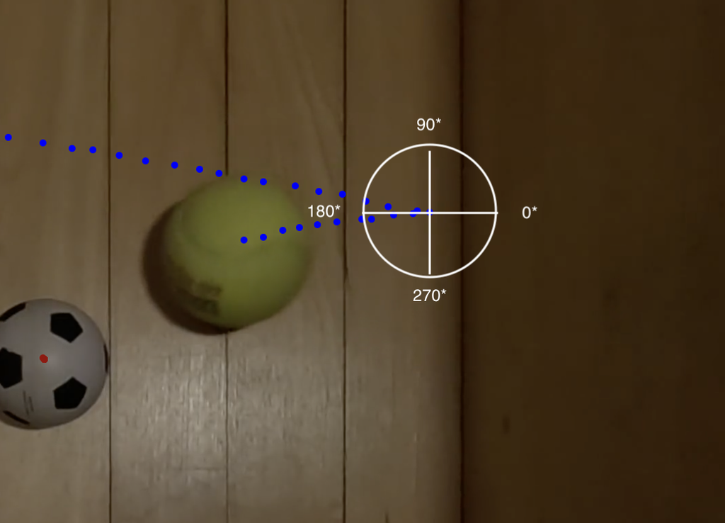